# Report

Wenxuan Qi

03/13/2022

# 1 Abstract

In recent 2 years, COVID-19 has become an important issue in people’s lives. It transmits very fast and even causes deaths. All country put into efforts to resolve the tough situation. Vaccinations are developed soon after the outbreaks. Various regulations are set such as stay-at-home and social distancing policies. This report explore the COVID-19 dataset and the vaccination dataset from World Health Organization to answer 2 main questions. After doing statistical analysis, it is concluded that there exist regional effect and vaccination effect on case-fatality rate. Whereas, the test failed to recognize the combination with lowest mean case-fatality rate. Future studies could dig deeper into the regional effect to see its causes.

# 2 Introduction

The COVID-19 pandemic has been an unprecedented event that influenced people’s lives and caused severe results. The case-fatality rate is one of the concerning metrics related to COVID-19. The disease could cause death, and it is urgent for people to find a way to avoid this. As the pandemic was firstly discovered in December 2019 and spread worldwide, scientists started to develop vaccinations to prevent the infectious disease. There are various brands of vaccinations that were developed at different time and used in different countries. The vaccination effect is always a concerning aspect that both the company that produces it and people who use it care about. The COVID-19 situation is still quickly changing all the time, while governments issue different regulations related to vaccination. Therefore, besides vaccination factor, region is another factor that this report will look at. To investigate the potential influencing factors, this report uses 2 datasets from World Health Organization, COVID-19 daily data and COVID-19 vaccination data, and focuses on 2 main questions:

1. Are there any effects of Region and whether vaccination has been used on case-fatality rate?
2. If these two effects are proved significant, which cell have the lowest case-fatality rate?

# 3 Background

Two datasets are used in this project. Both of them are official data from the World Health Organization, which is a reliable source. Since countries started vaccination at different time and the question of interest involves the effect of vaccination use, the target countries are all countries data record in the dataset. Also, countries are located in various regions, which provides enough data record for each region to explore the effect of region. As the first case appeared in different countries at various time, the target time period is from the date the first case appeared to Mar.3rd, 2022.

## 3.1 WHO COVID-19 dataset

The World Health Organization COVID-19 dataset contains over 180,000 daily records of different countries from January 2020 to February 2022. It records countries information, reported date and corresponding number of new cases, number of cumulative cases, number of new deaths and number of cumulative deaths. The region information is used to analyze records at a regional level. The number of new cases and number of new deaths are used to calculate the case-fatality rate per record.

## 3.2 WHO COVID-19 Vaccination dataset

The COVID-19 Vaccination dataset from World Health Organization contains statistics of vaccination uses, the date begin to use vaccination and vaccination information reported by 228 countries in the world. The start date of vaccination and number of used vaccination types are utilized to explore the effect of vaccination and how do vaccination types perform in detail.

## 3.3 Variables

1. Case-fatality rate: It is firstly calculated as $\frac{Number~of~New~Deaths}{Number~of~New~Cases}$. This outputs a fatality rate of every record that reported by different countries in different days. The virus has incubation time period of 7 days, so the final case-fatality rate is further calculated by running 7-day average.
2. WHO_Region: It is a categorical variable having 6 levels: AFRO(African Region), AMRO(Region of the Americas), SEARO(South-East Asian Region), EURO(European Region), EMRO(Eastern Mediterranean Region), WPRO(Western Pacific Region).
3. Started_Vac: It is a categorical variable having 2 levels: yes, no. After the 2 datasets are joined together by country, this variable is calculated as comparing the reported date of each record and the first day of using vaccination in its corresponding country.
4. Number_Vac_Type_Used: It is a categorical variable ranging from integers between 0 and 11, which indicates the number of vaccination type used in the country.

# 4 Descriptive analysis

```
##         Number of New Cases Number of New Deaths Case-fatality Rate
## Min.           1.000000e+00         0.000000e+00       0.000000e+00
## 1st Qu.        3.400000e+01         0.000000e+00       2.976190e-03
## Median         2.530000e+02         3.000000e+00       1.242051e-02
## Mean           3.784306e+03         5.015040e+01       2.676694e-02
## 3rd Qu.        1.392000e+03         1.900000e+01       2.857143e-02
## Max.           1.294746e+06         8.786000e+03       7.192965e+00
```

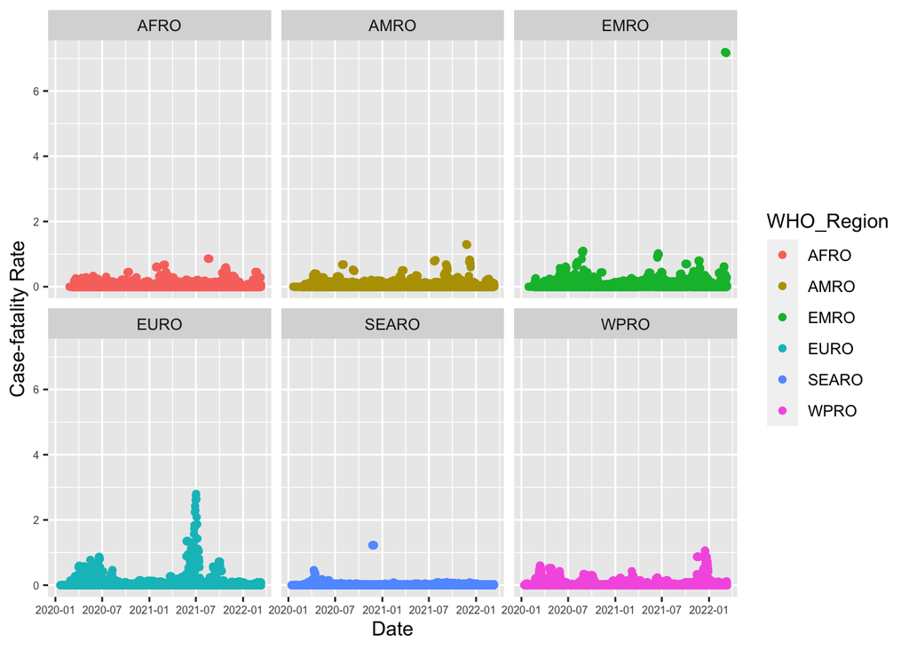

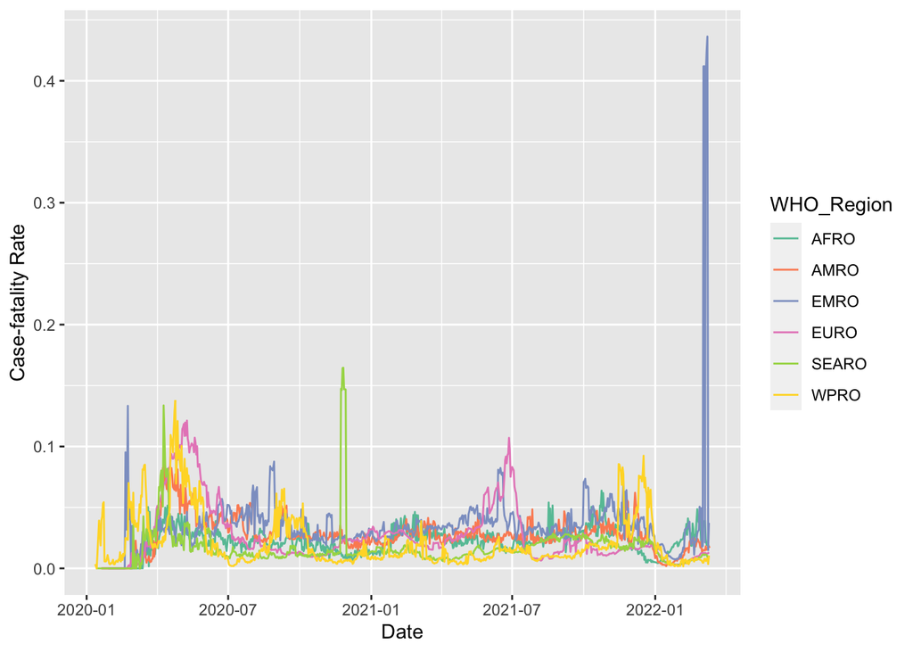

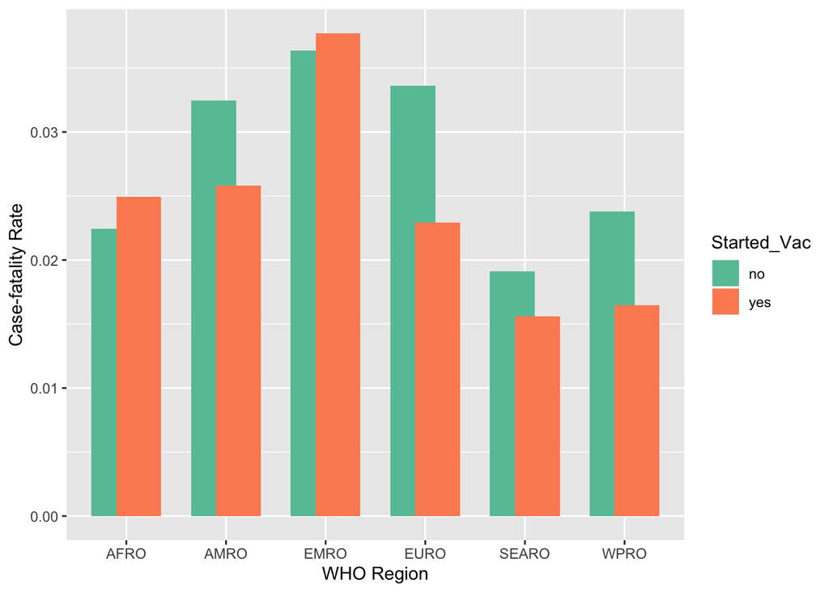

The plots shows differences in case-fatality rate within different region and vaccination period. The main effects and interactive effects of the 2 variables will be tested in following section.

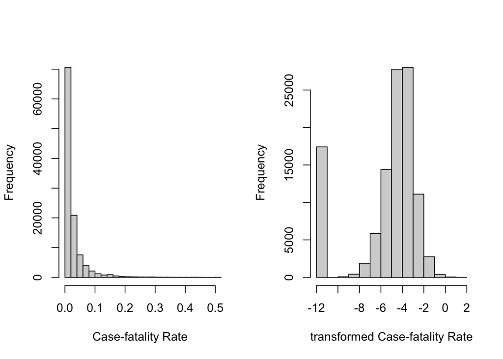

The case-fatality rate has a right-skewed distribution, and case-fatality = 0 has great amount of mass. We decide to transform the case-fatality rate as $Y^{'}_i = log(Y_i + 0.00001)$. The small shift helps fix the problem that when case-fatality rate = 0, the log transformation is not applicable. Despite there’s still mass at the left, the rest of the plot show normal distribution trend.

# 5 Inferential analysis

As proposed in the question of interest, the full two-way ANONA is defined as $Y_{ijk} = \mu_{..} + \alpha_{i} + \beta_{j} + (\alpha\beta)_{ij} + \epsilon_{ijk}$, where index $i$ represents the region, index $j$ represents the vaccination indicator and $\epsilon s$ are i.i.d $N(0, \sigma^2)$. The constraints include $\sum_i \alpha_i = \sum_j \beta_j = 0$ and $\sum_i (\alpha\beta)_{ij} = \sum_j (\alpha\beta)_{ij} = 0$.

To test whether we can drop the terms in full model, 3 F-tests are conducted at significance level $\alpha=0.05$. The F statistics is $F^* = \frac{[SSE_{red} - SSE_{full}]/[df_{red} - df_{full}]}{SSE_{full}/df_{full}}$.

## 5.2 F-test for main effects

After conducting all tests, the result(Table 1) indicates that the effects of WHO_Region, Started_Vac and the interaction effect are all significant to the case-fatality rate.

## 5.3 Tukey’s range test

```
##          diff           lwr           upr         p adj
##  0.0008402382 -0.0042001351  0.0058806115  0.9999941498
```

# 6 Sensitivity analysis

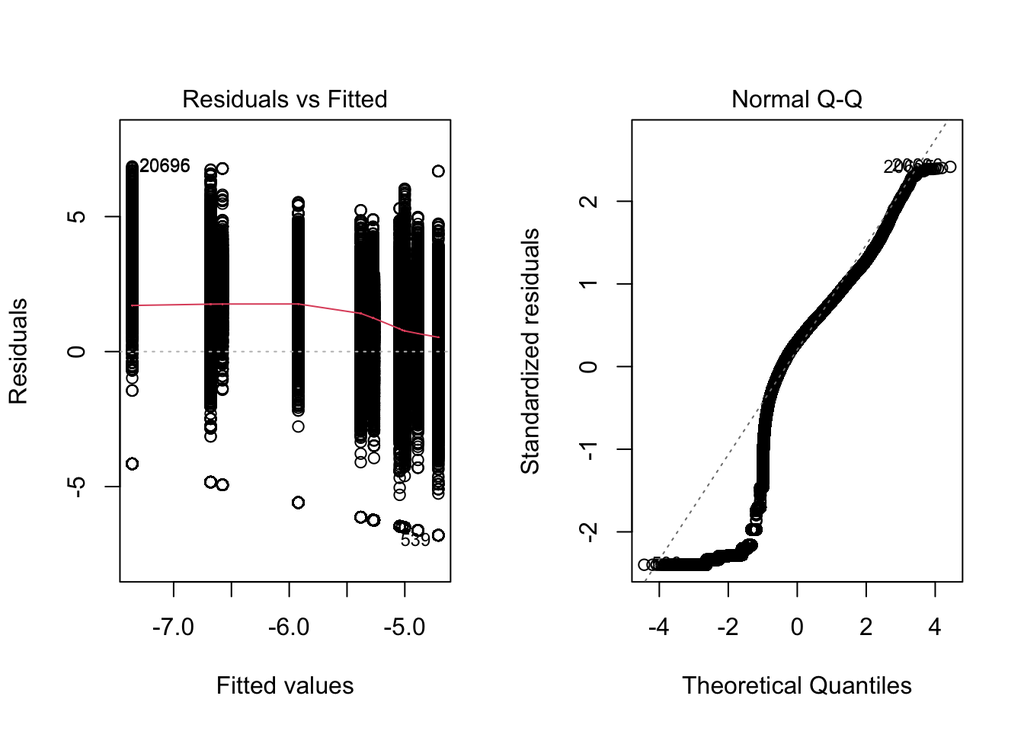

```r
s1 = summary(full_model)
s1
```

```
##
## Call:
## lm(formula = cf_rate ~ WHO_Region + Started_Vac + WHO_Region *
##     Started_Vac, data = my_data)
##
## Residuals:
##     Min      1Q  Median      3Q     Max
## -6.8028 -0.6343  0.8521  1.7953  6.8548
##
## Coefficients:
##                                Estimate Std. Error  t value Pr(>|t|)
## (Intercept)                    -5.92154    0.02701 -219.224  < 2e-16 ***
## WHO_RegionAMRO                  0.64666    0.03994   16.192  < 2e-16 ***
## WHO_RegionEMRO                  1.03506    0.04482   23.092  < 2e-16 ***
## WHO_RegionEURO                  0.89920    0.03565   25.224  < 2e-16 ***
## WHO_RegionSEARO                -0.65609    0.06068  -10.812  < 2e-16 ***
## WHO_RegionWPRO                 -1.43695    0.05235  -27.451  < 2e-16 ***
## Started_Vacyes                  0.54055    0.03841   14.074  < 2e-16 ***
## WHO_RegionAMRO:Started_Vacyes  -0.31004    0.05437   -5.702 1.18e-08 ***
## WHO_RegionEMRO:Started_Vacyes  -0.36418    0.06152   -5.920 3.23e-09 ***
## WHO_RegionEURO:Started_Vacyes  -0.51914    0.04924  -10.544  < 2e-16 ***
## WHO_RegionSEARO:Started_Vacyes  0.77060    0.08099    9.515  < 2e-16 ***
## WHO_RegionWPRO:Started_Vacyes   0.13811    0.06839    2.019   0.0434 *
## ---
## Signif. codes:  0 '***' 0.001 '**' 0.01 '*' 0.05 '.' 0.1 ' ' 1
##
## Residual standard error: 2.837 on 110162 degrees of freedom
## Multiple R-squared:  0.04894,    Adjusted R-squared:  0.04884
## F-statistic: 515.3 on 11 and 110162 DF,  p-value: < 2.2e-16
```

From the summary of the full model using linear regression, the probabilities of each level of WHO_Region, each level of Started_Vac and each combination between these 2 factors are all less than 0.05. With significance level $\alpha=0.05$, the two factors and interaction term are proved significant. The results are consistent with the results in the main analysis.

# 7 Discussion

1. Both region and whether vaccination is used have impact on case-fatality rate.
2. There’s no cell would obtain the lowest mean case-fatality rate statistically.

For future research, the project could be developed in ways such as improving the calculation of case-fatality rate to avoid extreme values. As discovered in this project, there’s regional effect on case-fatality rate, then further research could explore the specific factors that would cause the regional effect, such as demographical approach, economical approach and geographical approach.

https://github.com/7qiwx/207project

# 8 Appendix

Table 1

|  | Sum Sq | Df | F value | Pr(>F) |
| --- | --- | --- | --- | --- |
| WHO_Region | 40137.211 | 5 | 997.39746 | 0.000000e+00 |
| Started_Vac | 2859.968 | 1 | 355.34667 | 3.870202e-79 |
| WHO_Region:Started_Vac | 3014.569 | 5 | 74.91113 | 1.231983e-78 |
| Residuals | 886626.577 | 110162 | NA | NA |

Table 2

```
##               no        yes
## AFRO  0.02244586 0.02495570
## AMRO  0.03245317 0.02579388
## EMRO  0.03635114 0.03771954
## EURO  0.03361526 0.02290921
## SEARO 0.01910383 0.01561720
## WPRO  0.02379154 0.01645744
```

Table 3

```
##          diff           lwr           upr         p adj
##  0.0008402382 -0.0042001351  0.0058806115  0.9999941498
```